# P8106 Data Science II Final Project

Stephanie Zhen, Xinran Luo, Ran An

5/4/2020

```r
library(tidyverse)
library(readr)
library(Amelia)
library(DataExplorer)
library(caret)
library(pROC)
library(ROCR)
library(klaR)
library(AppliedPredictiveModeling)
library(naivebayes)
```

```r
library(rpart.plot)
```

age: age in years

sex: (1 = male; 0 = female)

cp: chest pain type (typical angina, atypical angina, non-angina, or asymptomatic angina)

trestbps: resting blood pressure (in mm Hg on admission to the hospital)

chol: serum cholestoral in mg/dl

fbs: Fasting blood sugar (< 120 mg/dl or > 120 mg/dl) (1 = true; 0 = false)

restecg: resting electrocardiographic results (normal, ST-T wave abnormality, or left ventricular hypertrophy)

thalach: Max. heart rate achieved during thalium stress test

exang: Exercise induced angina (1 = yes; 0 = no)

oldpeak: ST depression induced by exercise relative to rest

ca: number of major vessels (0-3) colored by flourosopy 4 = NA

target: Heart disease status 1 or 0 (0 = heart disease 1 = asymptomatic)

### Load the data

```r
heart = read_csv("./data/heart.csv")
head(heart)
```

```
## # A tibble: 6 x 14
##     age   sex    cp trestbps  chol   fbs restecg thalach exang oldpeak slope
##   <dbl> <dbl> <dbl>    <dbl> <dbl> <dbl>   <dbl>   <dbl> <dbl>   <dbl> <dbl>
## 1    63     1     3      145   233     1       0     150     0     2.3     0
## 2    37     1     2      130   250     0       1     187     0     3.5     0
## 3    41     0     1      130   204     0       0     172     0     1.4     2
## 4    56     1     1      120   236     0       1     178     0     0.8     2
## 5    57     0     0      120   354     0       1     163     1     0.6     2
## 6    57     1     0      140   192     0       1     148     0     0.4     1
## # ... with 3 more variables: ca <dbl>, thal <dbl>, target <dbl>
```

```r
summary(heart)
```

```
##       age             sex               cp           trestbps
##  Min.   :29.00   Min.   :0.0000   Min.   :0.000   Min.   : 94.0
##  1st Qu.:47.50   1st Qu.:0.0000   1st Qu.:0.000   1st Qu.:120.0
##  Median :55.00   Median :1.0000   Median :1.000   Median :130.0
##  Mean   :54.37   Mean   :0.6832   Mean   :0.967   Mean   :131.6
##  3rd Qu.:61.00   3rd Qu.:1.0000   3rd Qu.:2.000   3rd Qu.:140.0
##  Max.   :77.00   Max.   :1.0000   Max.   :3.000   Max.   :200.0
##       chol            fbs            restecg          thalach
##  Min.   :126.0   Min.   :0.0000   Min.   :0.0000   Min.   : 71.0
##  1st Qu.:211.0   1st Qu.:0.0000   1st Qu.:0.0000   1st Qu.:133.5
##  Median :240.0   Median :0.0000   Median :1.0000   Median :153.0
##  Mean   :246.3   Mean   :0.1485   Mean   :0.5281   Mean   :149.6
##  3rd Qu.:274.5   3rd Qu.:0.0000   3rd Qu.:1.0000   3rd Qu.:166.0
##  Max.   :564.0   Max.   :1.0000   Max.   :2.0000   Max.   :202.0
##      exang           oldpeak         slope             ca
##  Min.   :0.0000   Min.   :0.00   Min.   :0.000   Min.   :0.0000
##  1st Qu.:0.0000   1st Qu.:0.00   1st Qu.:1.000   1st Qu.:0.0000
##  Median :0.0000   Median :0.80   Median :1.000   Median :0.0000
##  Mean   :0.3267   Mean   :1.04   Mean   :1.399   Mean   :0.7294
##  3rd Qu.:1.0000   3rd Qu.:1.60   3rd Qu.:2.000   3rd Qu.:1.0000
##  Max.   :1.0000   Max.   :6.20   Max.   :2.000   Max.   :4.0000
##       thal           target
##  Min.   :0.000   Min.   :0.0000
##  1st Qu.:2.000   1st Qu.:0.0000
##  Median :2.000   Median :1.0000
##  Mean   :2.314   Mean   :0.5446
##  3rd Qu.:3.000   3rd Qu.:1.0000
##  Max.   :3.000   Max.   :1.0000
```

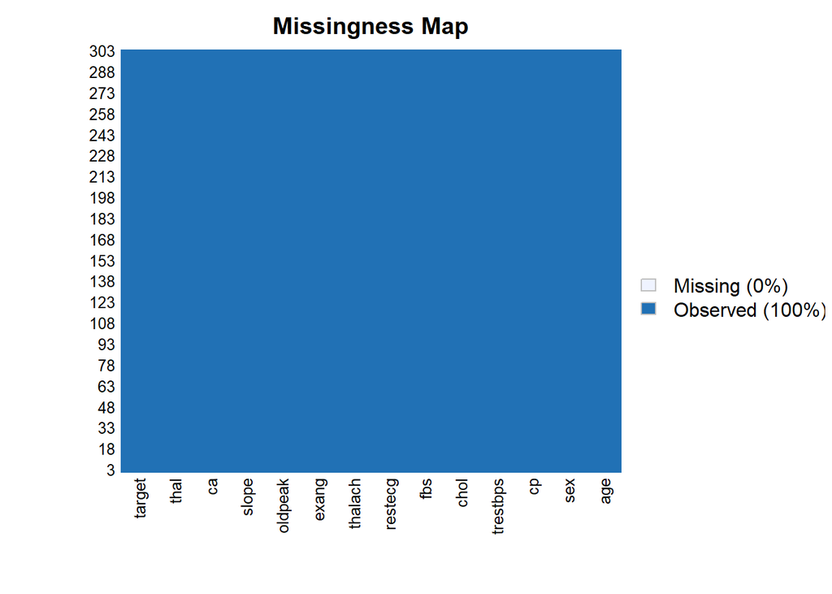

```r
missmap(heart)
```

###Data Cleaning:

```r
heart_nomiss = heart %>%
  filter(thal != 0 & ca != 4) %>%
  mutate(
    sex = case_when(
     sex == 1 ~ "male",
    sex == 0 ~ "female"
           ),
    fbs = case_when(
      fbs == 1 ~ "true",
      fbs == 0 ~ "false"
            ),
    exang = case_when(
      exang == 1 ~ "yes",
      exang == 0 ~ "no"
            ),
    cp = case_when(
      cp == 3 ~ "typical_angina",
      cp == 1 ~ "atypical_angina",
      cp == 2 ~ "non_anginal",
      cp == 0 ~ "asymptomatic_angina"
          ),
    restecg = case_when(
      restecg == 2 ~ "wave_abnormality",
      restecg == 1 ~ "normal",
      restecg == 0 ~ "hypertrophy"
              ),
    target = case_when(
      target == 1 ~ "asymptomatic",
      target == 0 ~ "heart_disease"
              ),
    slope = case_when(
      slope == 2 ~ "upsloping",
      slope == 1 ~ "flat",
      slope == 0 ~ "downsloping"
    ),
    thal = case_when(
      thal == 3 ~ "reversable_defect",
      thal == 2 ~ "normal",
      thal == 1 ~ "fixed_defect"
    ),
    sex = as.factor(sex),
    fbs = as.factor(fbs),
    exang = as.factor(exang),
    cp = as.factor(cp),
    slope = as.factor(slope),
    ca = as.factor(ca),
    thal = as.factor(thal)
  )
```

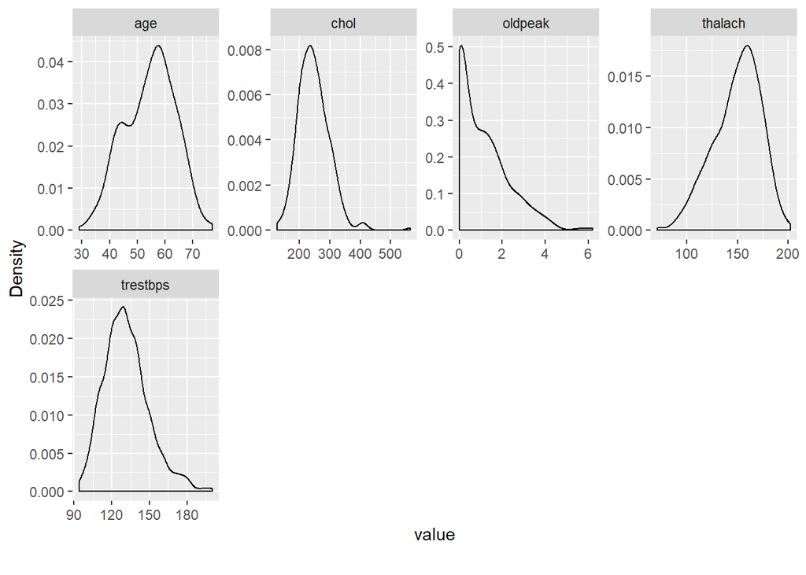

```r
plot_density(heart_nomiss)
```

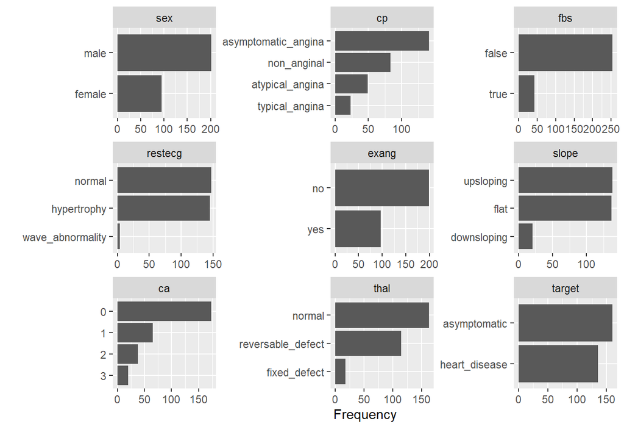

```r
plot_bar(heart_nomiss)
```

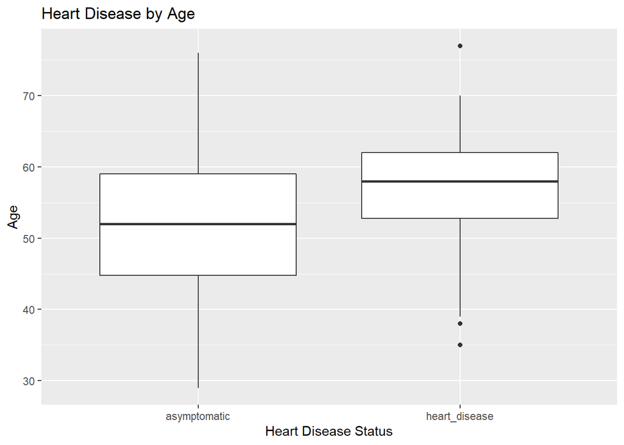

```r
### Age vs outcome(target)
ggplot(data = heart_nomiss, aes(x = target, y = age)) +
  geom_boxplot() +
  labs(x = "Heart Disease Status",
       y = "Age",
       title = "Heart Disease by Age")
```

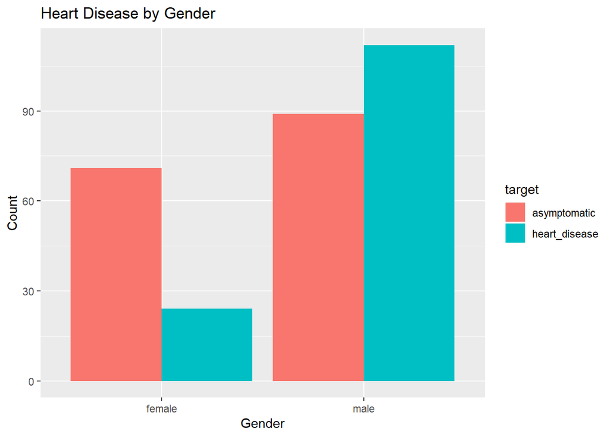

```r
### CP vs outcome(target)
#ggplot(data = heart_nomiss, aes(x = cp,
                                #fill = target)) +
  #geom_bar(position = position_dodge())

### Gender vs outcome(target)
ggplot(data = heart_nomiss, aes(x = sex,
                                fill = target)) +
  geom_bar(position = position_dodge()) +
  labs(x = "Gender",
       y = "Count",
       title = "Heart Disease by Gender")
```

###Partition the data for training

```r
set.seed(1)
train.indices <- createDataPartition(y = heart_nomiss$target, p = 0.7, list = FALSE)

training <- heart_nomiss[train.indices,]
testing <- heart_nomiss[-train.indices,]
```

###Naive Bayes (NB)

```r
set.seed(1)

heart.nb = naive_bayes(as.factor(target) ~ ., data = training)
nb.pred <- predict(heart.nb, newdata = testing, type = "prob")[,2]
roc.nb <- roc(testing$target, nb.pred)
```

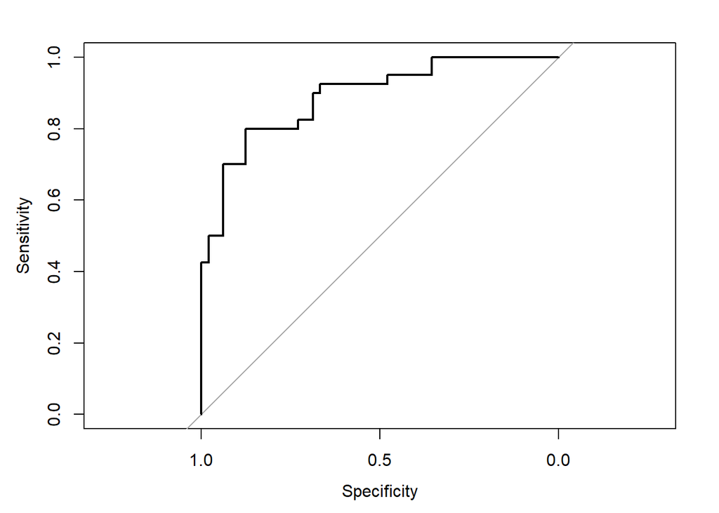

```r
#ROC curve
plot(roc.nb)
```

```r
roc.nb$auc
```

```
## Area under the curve: 0.8896
```

## rpart

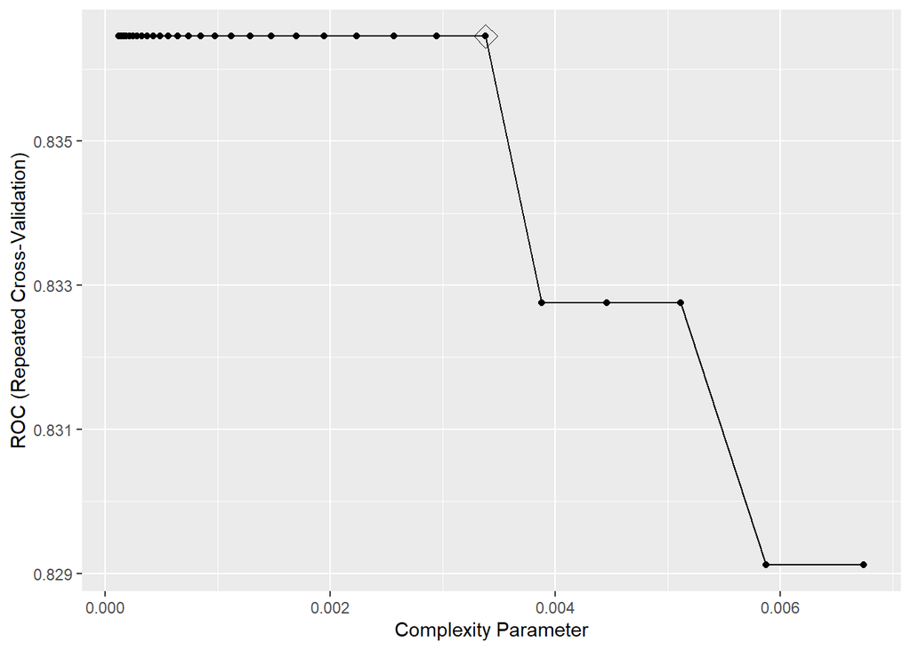

```r
control1 = trainControl(method = "repeatedcv",
                        summaryFunction = twoClassSummary,
                        classProbs = TRUE)

set.seed(1)
rpart_fit = train(target ~ .,
                  data = training,
                  method = "rpart",
                  tuneGrid = data.frame(cp = exp(seq(-9, -5, len = 30))),
                  trControl = control1,
                  metric = "ROC")

ggplot(rpart_fit, highlight = TRUE)
```

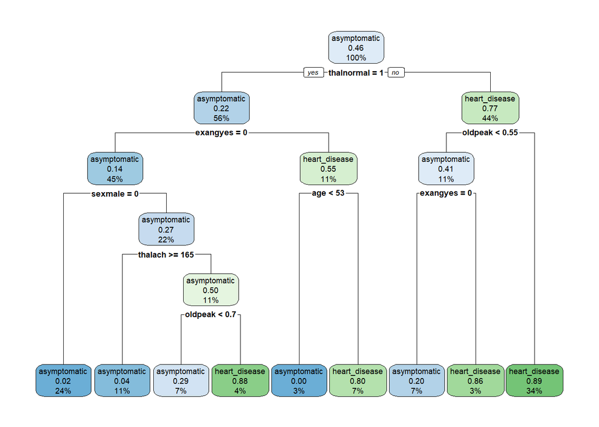

```r
rpart.plot(rpart_fit$finalModel)
```